# Visualization in R

# Analiza sluzaca realizacji celu (odpowiedzi na postawione pytania)

Podzial zbioru na testowy i treningowy

```r
df_nrow <- nrow(df)
tr_part <- 0.80
set.seed(765)

tr_index <- sample.int(df_nrow, floor(tr_part*df_nrow), replace = FALSE) #losowanie bez zwracania

train <- df[tr_index,]
test <- df[-tr_index,]
```

Tworzenie modelu - liniowego. Próba stworzenia przy uzyciu wszystkich zmiennych (próba wylowienia zmiennych znaczacych)

```r
linear <- lm(mark~ size_bytes+price+rating_count_tot+prime_genre+ipadSc_urls.num+lang.num +vpp_lic+main_release,train)

summary(linear)
```

```
##
## Call:
## lm(formula = mark ~ size_bytes + price + rating_count_tot + prime_genre +
##     ipadSc_urls.num + lang.num + vpp_lic + main_release, data = train)
##
## Residuals:
##     Min      1Q  Median      3Q     Max
## -1.1357 -0.0578  0.1580  0.2295  0.7083
##
## Coefficients:
##                                Estimate Std. Error t value Pr(>|t|)
## (Intercept)                   7.882e-02  7.860e-02   1.003 0.315944
## size_bytes                    3.585e-11  1.583e-11   2.265 0.023572 *
## price                         3.007e-03  1.107e-03   2.717 0.006607 **
## rating_count_tot              2.953e-07  6.976e-08   4.233 2.34e-05 ***
## prime_genreBusiness           2.580e-01  7.342e-02   3.514 0.000445 ***
## prime_genreCatalogs          -2.033e-01  1.566e-01  -1.299 0.194107
## prime_genreEducation          1.569e-01  4.750e-02   3.303 0.000962 ***
## prime_genreEntertainment      1.117e-01  4.665e-02   2.395 0.016656 *
## prime_genreFinance            2.129e-02  6.112e-02   0.348 0.727627
## prime_genreFood & Drink       2.010e-01  6.967e-02   2.885 0.003924 **
## prime_genreGames              2.537e-01  4.317e-02   5.877 4.43e-09 ***
## prime_genreHealth & Fitness   2.992e-01  5.425e-02   5.516 3.62e-08 ***
## prime_genreLifestyle          1.125e-01  5.629e-02   1.999 0.045680 *
## prime_genreMedical            2.201e-01  1.060e-01   2.076 0.037951 *
## prime_genreMusic              3.288e-01  5.698e-02   5.770 8.34e-09 ***
## prime_genreNavigation         1.849e-01  8.150e-02   2.269 0.023335 *
## prime_genreNews               1.541e-01  6.673e-02   2.309 0.020958 *
## prime_genrePhoto & Video      2.700e-01  4.878e-02   5.535 3.26e-08 ***
## prime_genreProductivity       3.078e-01  5.433e-02   5.664 1.55e-08 ***
## prime_genreReference          1.879e-01  6.903e-02   2.722 0.006516 **
## prime_genreShopping           2.767e-01  5.703e-02   4.852 1.25e-06 ***
## prime_genreSocial Networking  1.156e-01  5.462e-02   2.117 0.034295 *
## prime_genreSports             5.733e-02  6.196e-02   0.925 0.354816
## prime_genreTravel             1.960e-01  6.583e-02   2.977 0.002926 **
## prime_genreUtilities          1.624e-01  5.041e-02   3.222 0.001282 **
## prime_genreWeather            2.692e-01  6.674e-02   4.033 5.58e-05 ***
## ipadSc_urls.num               4.379e-02  2.940e-03  14.896  < 2e-16 ***
## lang.num                      7.177e-03  6.931e-04  10.355  < 2e-16 ***
## vpp_lic1                      2.482e-01  6.608e-02   3.756 0.000174 ***
## main_release                  1.927e-05  1.584e-05   1.216 0.223929
## ---
## Signif. codes:  0 '***' 0.001 '**' 0.01 '*' 0.05 '.' 0.1 ' ' 1
##
## Residual standard error: 0.3987 on 5722 degrees of freedom
##   (5 observations deleted due to missingness)
## Multiple R-squared:  0.1262, Adjusted R-squared:  0.1217
## F-statistic: 28.49 on 29 and 5722 DF,  p-value: < 2.2e-16
```

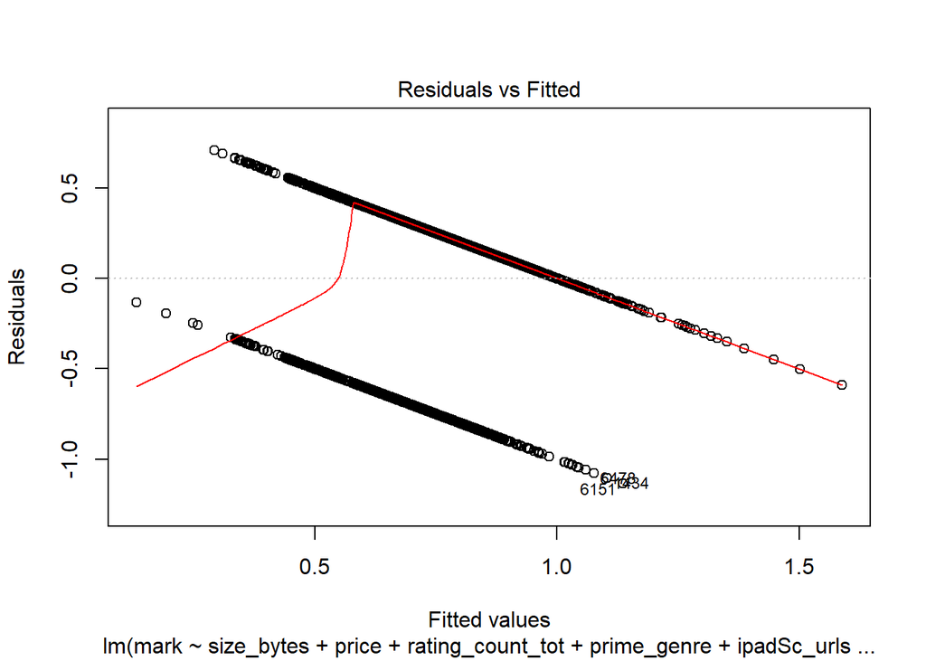

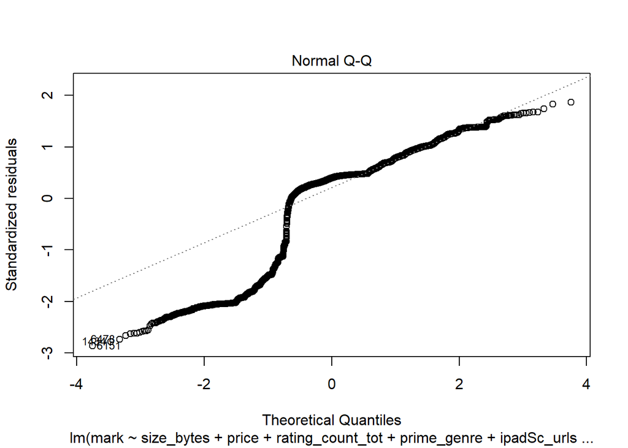

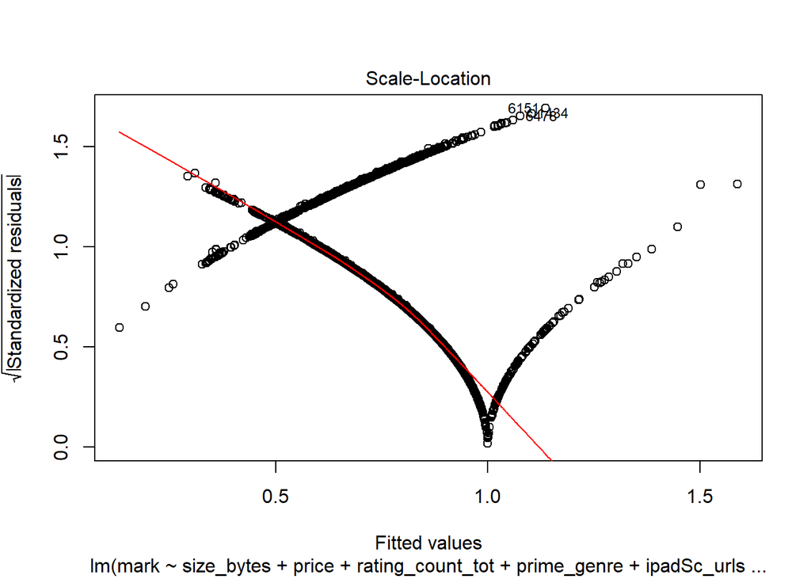

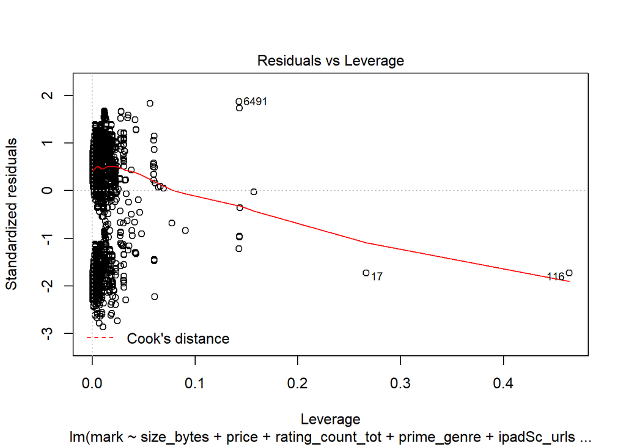

```r
plot(linear)
```

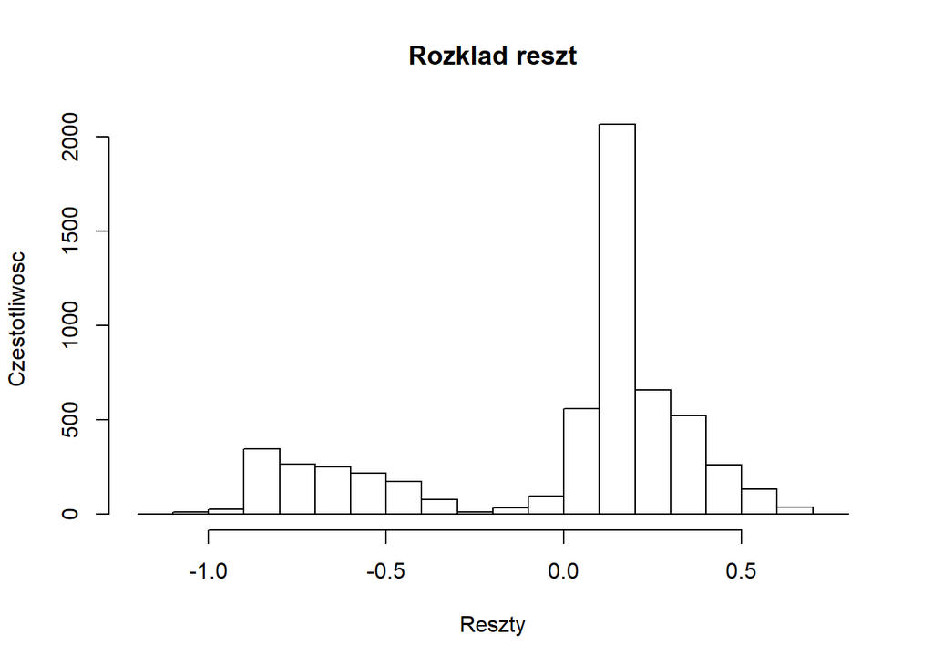

```r
hist(linear$residuals, xlab = "Reszty", ylab = "Czestotliwosc", main = "Rozklad reszt")
```

Aplikacja danych

```r
predict_linear <- predict(linear, newdata = test)

summary(predict_linear)
```

```
##    Min. 1st Qu.  Median    Mean 3rd Qu.    Max.    NA's
##  0.1315  0.6706  0.8105  0.7591  0.8494  1.6331       1
```

```r
predict_m1 <- predict_linear

predict_m1[predict_linear>=0.5] <- 1
predict_m1[predict_linear<0.5] <- 0


library(caret)
conf_matrix_ml<- confusionMatrix(factor(predict_m1, levels=c(1,0)), factor(test$mark, levels=c(1,0)))

conf_matrix_ml
```

```
## Confusion Matrix and Statistics
##
##           Reference
## Prediction    1    0
##          1 1052  274
##          0   39   74
##
##                Accuracy : 0.7825
##                  95% CI : (0.7603, 0.8036)
##     No Information Rate : 0.7582
##     P-Value [Acc > NIR] : 0.01603
##
##                   Kappa : 0.2297
##  Mcnemar's Test P-Value : < 2e-16
##
##             Sensitivity : 0.9643
##             Specificity : 0.2126
##          Pos Pred Value : 0.7934
##          Neg Pred Value : 0.6549
##              Prevalence : 0.7582
##          Detection Rate : 0.7311
##    Detection Prevalence : 0.9215
##       Balanced Accuracy : 0.5884
##
##        'Positive' Class : 1
##
```

W pierwszej iteracji projektu (na innym zestawie danych), pojawil sie w tym miejscu warning, który wydaje mi sie, ze warto go zaadresowac. Warning wynikal z faktu, ze nie równo podzielono zmienne kategoryczne miedzy zestaw testowy i treningowy. Funkcje glm() i predict() rzutuja zmienne typu character na factor - jezeli nie zostana one podzielone równo pomiedzy zestawy treningowe i testowe. W momencie stosowania funkcji predict() tworza sie nowe poziomy factora, które nie braly udzialu w tworzeniu modelu, w zwiazku z czym funkcja predict nie wie w jaki sposób je potraktowac i jaki maja one wplyw na wynik, co rezultuje bledem i zakonczeniem dzialania skryptu. Technicznie moze to tez wynikac z faktu, ze funkcje glm() i predict() radza sobie ze zmiennymi typu factor tworzac dla kazdego poziomu dodatkowe kolumny (czyli jezeli mamy factor o 3 poziomach tworza sie 3 kolumny w zasadzie typu boolowskiego, majace 1 dla kolumny odpowiadajacej wartosci factora w danym wierszu, 0 w pozostalych) - jest to problematyczne, ale mysle, ze jest to jeden z problemów jaki mozna by zlikwidowac tworzac kilka podzialów na zbiory terningowe i testowe i wybór najlepszego (najciekawsza dla mnie metoda jest podzial kroczacy - tzn. jezeli biore 20 % do testowego,to nalezaloby stworzyc 5 zbiorów testowych, których sumach bylaby równa calosci danych.)

W tym wypadku podejrzewam, ze ten model moze byc az zbyt dobrze dopasowany do danych treningowych i nie sprawdzic sie na danych testowych.

```r
library(pROC)
logistic <- glm(data = train, mark~ size_bytes+price+rating_count_tot+prime_genre+ipadSc_urls.num+lang.num +vpp_lic+main_release, family = "binomial")
summary(logistic)
```

```
##
## Call:
## glm(formula = mark ~ size_bytes + price + rating_count_tot +
##     prime_genre + ipadSc_urls.num + lang.num + vpp_lic + main_release,
##     family = "binomial", data = train)
##
## Deviance Residuals:
##     Min       1Q   Median       3Q      Max
## -4.6608   0.0778   0.5387   0.6861   1.7655
##
## Coefficients:
##                                Estimate Std. Error z value Pr(>|z|)
## (Intercept)                  -2.478e+00  4.352e-01  -5.694 1.24e-08 ***
## size_bytes                    2.250e-10  1.271e-10   1.770 0.076799 .
## price                         5.930e-02  1.582e-02   3.750 0.000177 ***
## rating_count_tot              1.764e-05  2.900e-06   6.083 1.18e-09 ***
## prime_genreBusiness           1.142e+00  4.958e-01   2.304 0.021233 *
## prime_genreCatalogs          -8.376e-01  8.856e-01  -0.946 0.344256
## prime_genreEducation          6.006e-01  2.612e-01   2.299 0.021497 *
## prime_genreEntertainment      4.363e-01  2.519e-01   1.732 0.083284 .
## prime_genreFinance            7.872e-02  3.309e-01   0.238 0.811950
## prime_genreFood & Drink       8.624e-01  3.869e-01   2.229 0.025822 *
## prime_genreGames              1.172e+00  2.339e-01   5.012 5.39e-07 ***
## prime_genreHealth & Fitness   1.353e+00  3.162e-01   4.278 1.88e-05 ***
## prime_genreLifestyle          4.835e-01  3.032e-01   1.595 0.110752
## prime_genreMedical            8.824e-01  6.716e-01   1.314 0.188883
## prime_genreMusic              1.774e+00  4.015e-01   4.418 9.94e-06 ***
## prime_genreNavigation         7.845e-01  4.698e-01   1.670 0.094980 .
## prime_genreNews               6.596e-01  3.636e-01   1.814 0.069675 .
## prime_genrePhoto & Video      1.217e+00  2.798e-01   4.348 1.38e-05 ***
## prime_genreProductivity       1.732e+00  3.612e-01   4.796 1.62e-06 ***
## prime_genreReference          6.915e-01  4.054e-01   1.706 0.088099 .
## prime_genreShopping           1.252e+00  3.237e-01   3.869 0.000109 ***
## prime_genreSocial Networking  4.141e-01  3.021e-01   1.371 0.170500
## prime_genreSports             1.379e-01  3.358e-01   0.411 0.681223
## prime_genreTravel             9.020e-01  3.745e-01   2.408 0.016025 *
## prime_genreUtilities          6.487e-01  2.760e-01   2.350 0.018783 *
## prime_genreWeather            1.227e+00  4.110e-01   2.987 0.002819 **
## ipadSc_urls.num               2.174e-01  1.705e-02  12.748  < 2e-16 ***
## lang.num                      6.184e-02  6.597e-03   9.374  < 2e-16 ***
## vpp_lic1                      1.461e+00  3.660e-01   3.991 6.58e-05 ***
## main_release                  3.803e-04  4.030e-04   0.944 0.345333
## ---
## Signif. codes:  0 '***' 0.001 '**' 0.01 '*' 0.05 '.' 0.1 ' ' 1
##
## (Dispersion parameter for binomial family taken to be 1)
##
##     Null deviance: 6303.7  on 5751  degrees of freedom
## Residual deviance: 5488.0  on 5722  degrees of freedom
##   (5 observations deleted due to missingness)
## AIC: 5548
##
## Number of Fisher Scoring iterations: 7
```

```r
#plot(logistic)
#hist(logistic$residuals, xlab = "Reszty", ylab = "Czestotliwosc", main = "Rozklad reszt")

predict_logistic <- predict(logistic, newdata = test, type = "response")

summary(predict_logistic)
```

```
##    Min. 1st Qu.  Median    Mean 3rd Qu.    Max.    NA's
##  0.1436  0.6795  0.7997  0.7590  0.8737  1.0000       1
```

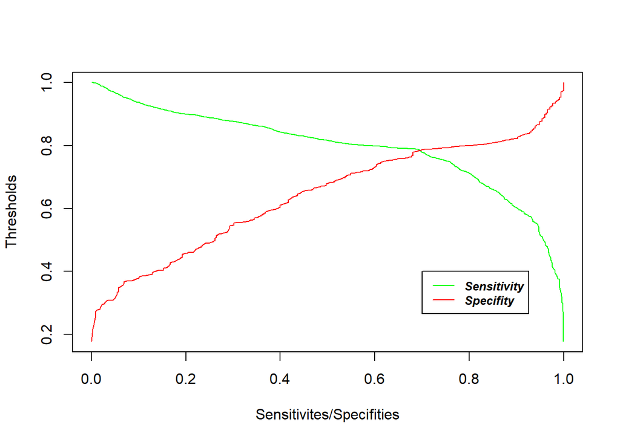

```r
roc_logistic <- roc(as.numeric(test$mark), predict_logistic, direction="<")

plot(roc_logistic$sensitivities, roc_logistic$thresholds, type = "l", col="green", xlab = "Sensitivites/Specifities", ylab = "Thresholds")
lines(roc_logistic$specificities, roc_logistic$thresholds, col="red")
legend(0.7, 0.4, legend=c("Sensitivity", "Specifity"),
       col=c("green", "red"), lty=1, cex=0.8,
       text.font=4)
```

```r
threshold <- mean(roc_logistic$thresholds[abs(roc_logistic$sensitivities-roc_logistic$specificities)<=0.005])

predict_m2 <- predict_logistic

predict_m2[predict_logistic>=threshold] <- 1
predict_m2[predict_logistic<threshold] <- 0

conf_matrix_mlg<- confusionMatrix(factor(predict_m2, levels=c(1,0)), factor(test$mark, levels=c(1,0)))

conf_matrix_mlg
```

```
## Confusion Matrix and Statistics
##
##           Reference
## Prediction   1   0
##          1 760 105
##          0 331 243
##
##                Accuracy : 0.697
##                  95% CI : (0.6725, 0.7207)
##     No Information Rate : 0.7582
##     P-Value [Acc > NIR] : 1
##
##                   Kappa : 0.3234
##  Mcnemar's Test P-Value : <2e-16
##
##             Sensitivity : 0.6966
##             Specificity : 0.6983
##          Pos Pred Value : 0.8786
##          Neg Pred Value : 0.4233
##              Prevalence : 0.7582
##          Detection Rate : 0.5281
##    Detection Prevalence : 0.6011
##       Balanced Accuracy : 0.6974
##
##        'Positive' Class : 1
##
```

Drzewo decyzyjne

```r
library(rpart)
library(rpart.plot)
tree <- rpart(mark~ size_bytes+price+rating_count_tot+prime_genre+ipadSc_urls.num+lang.num +vpp_lic+main_release, data=train)

summary(tree)
```

```
## Call:
## rpart(formula = mark ~ size_bytes + price + rating_count_tot +
##     prime_genre + ipadSc_urls.num + lang.num + vpp_lic + main_release,
##     data = train)
##   n= 5757
##
##           CP nsplit rel error    xerror       xstd
## 1 0.47119463      0 1.0000000 1.0001852 0.01628177
## 2 0.02924598      1 0.5288054 0.5289240 0.01708869
## 3 0.01873839      2 0.4995594 0.5121452 0.01620151
## 4 0.01000000      3 0.4808210 0.4880325 0.01491997
##
## Variable importance
## rating_count_tot      prime_genre
##               94                6
##
## Node number 1: 5757 observations,    complexity param=0.4711946
##   mean=0.7627236, MSE=0.1809763
##   left son=2 (736 obs) right son=3 (5021 obs)
##   Primary splits:
##       rating_count_tot < 0.5        to the left,  improve=0.47119460, (0 missing)
##       ipadSc_urls.num  < 4.5        to the left,  improve=0.06281500, (0 missing)
##       lang.num         < 3.5        to the left,  improve=0.05388842, (0 missing)
##       prime_genre      splits as  LRLRLLLRRLRRLLRRRRLLLLR, improve=0.04493982, (0 missing)
##       size_bytes       < 52509180   to the left,  improve=0.04214684, (0 missing)
##   Surrogate splits:
##       prime_genre splits as  RRLRRRRRRRRRRRRRRRRRRRR, agree=0.873, adj=0.004, (0 split)
##       size_bytes  < 3908366000 to the right, agree=0.873, adj=0.003, (0 split)
##       lang.num    < 0.5        to the left,  agree=0.872, adj=0.001, (0 split)
##
## Node number 2: 736 observations
##   mean=0, MSE=0
##
## Node number 3: 5021 observations,    complexity param=0.02924598
##   mean=0.874527, MSE=0.1097295
##   left son=6 (1029 obs) right son=7 (3992 obs)
##   Primary splits:
##       prime_genre      splits as  RRRRLLLRRLRRRLRRRRLLLLR, improve=0.05530575, (0 missing)
##       rating_count_tot < 107.5      to the left,  improve=0.04912302, (0 missing)
##       ipadSc_urls.num  < 4.5        to the left,  improve=0.03235253, (0 missing)
```

[output cut: 10 more lines]

```
##       rating_count_tot < 107.5      to the left,  improve=0.062269110, (0 missing)
##       size_bytes       < 28941820   to the left,  improve=0.021288080, (0 missing)
##       ipadSc_urls.num  < 4.5        to the left,  improve=0.017435460, (0 missing)
##       lang.num         < 4.5        to the left,  improve=0.009190092, (0 missing)
##       prime_genre      splits as  RLRL---RL-LRL-LRRL----L, improve=0.008295467, (0 missing)
##   Surrogate splits:
##       prime_genre  splits as  LRRR---RR-LRR-RRRR----R, agree=0.718, adj=0.020, (0 split)
##       size_bytes   < 3302912    to the left,  agree=0.714, adj=0.007, (0 split)
##       main_release < 6673.5     to the right, agree=0.713, adj=0.003, (0 split)
##
## Node number 14: 1148 observations
##   mean=0.804007, MSE=0.1575798
##
## Node number 15: 2844 observations
##   mean=0.9585091, MSE=0.03976937
```

```r
tree
```

```
## n= 5757
##
## node), split, n, deviance, yval
##       * denotes terminal node
##
##  1) root 5757 1041.8800 0.7627236
##    2) rating_count_tot< 0.5 736    0.0000 0.0000000 *
##    3) rating_count_tot>=0.5 5021  550.9520 0.8745270
##      6) prime_genre=Entertainment,Finance,Food & Drink,Lifestyle,News,Social Networking,Sports,Travel,Utilities 1029  206.9524 0.7210884 *
##      7) prime_genre=Book,Business,Catalogs,Education,Games,Health & Fitness,Medical,Music,Navigation,Photo & Video,Productivity,Reference,Shopping,Weather 3992  313.5288 0.9140782
##       14) rating_count_tot< 107.5 1148  180.9016 0.8040070 *
##       15) rating_count_tot>=107.5 2844  113.1041 0.9585091 *
```

```r
printcp(tree)
```

```
##
## Regression tree:
## rpart(formula = mark ~ size_bytes + price + rating_count_tot +
##     prime_genre + ipadSc_urls.num + lang.num + vpp_lic + main_release,
##     data = train)
##
## Variables actually used in tree construction:
## [1] prime_genre      rating_count_tot
##
## Root node error: 1041.9/5757 = 0.18098
##
## n= 5757
##
##         CP nsplit rel error  xerror     xstd
## 1 0.471195      0   1.00000 1.00019 0.016282
## 2 0.029246      1   0.52881 0.52892 0.017089
## 3 0.018738      2   0.49956 0.51215 0.016202
## 4 0.010000      3   0.48082 0.48803 0.014920
```